[figure not shown]

# Digital Observatory

## About the Australian Twittersphere

### As at end of April 2023

The Australian Twittersphere is a longitudinal collection of tweets from a periodically updated list of Twitter accounts that are identified as Australian (i.e., have a *stated connection* to Australia in the free text fields of the account profile). The Australian Twittersphere is made up of three collections:

- In 2016, the [TrISMA project](https://research.qut.edu.au/dmrc/projects/trisma-tracking-infrastructure-for-social-media-analysis/) classified approximately 530,000 Twitter accounts as being *Australian* and began collecting tweets from those accounts. The TrISMA project concluded and tweets ceased being collected in May 2017. This collection is known as the ‘2016’ collection.
- In early 2018, the Digital Observatory was established and continued collecting tweets from the same accounts from approximately March 2018 to December 2018 using a streaming API. This collection is known as the ‘2018’ collection.
- In late 2018, the Digital Observatory developed an additional collector which began collecting tweets from the same accounts. This collection is currently active, and is known as our ‘current’ collection. As of December 2020, the list of accounts in the current collection is periodically updated according to a dictionary of phrases that include/exclude accounts as being Australian. Points in time at which the list of accounts was updated are represented by a vertical dashed lines in the figures below.

The following reference outlines how the Australian Twittersphere was originally established (pre-Digital Observatory):

Bruns, A., Burgess, J., Highfield, T. (2014). A ‘Big Data’ Approach to Mapping the Australian Twittersphere. In: Arthur P. L., Bode K. (eds) Advancing Digital Humanities. Palgrave Macmillan, London.  
https://link-springer-com.ezp01.library.qut.edu.au/chapter/10.1057/9781137337016_8

*Figure 1.* Number of tweets per month for all three collections (2016 onwards).

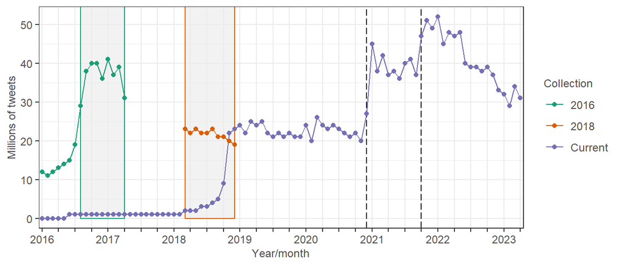

Figure 1 shows the number of tweets per month from 2016 onwards for all three collections that together form the Australian Twittersphere. The current collection has been running since November 2018 and collected an average of 23 million tweets per month until the beginning of December 2020. In December 2020, the list of accounts in the Australian Twittersphere was updated (represented by a dashed vertical line), and until October 2021 collected an average of 39 million tweets per month. In October 2021, the list of accounts was again updated, and to date has collected an average of 41 million tweets per month.

Over the period March to December 2018 (indicated by the grey shaded area with orange border), the 2018 collection collected an average of 22 million tweets per month. Over the period August 2016 to April 2017 (indicated by the grey shaded area with green border), the 2016 collection collected an average of 37 million tweets per month.

*Figure 2.* Number of tweets per month for all three collections (all available data).

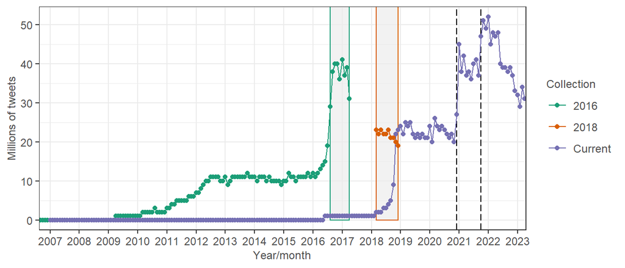

Figure 2 shows the same information as in Figure 1, but shows all available data back to as early as September 2006. The long tails that can be seen for the 2016 and current collections are due to the use of Twitter’s free developer API which enables limited collection of historical tweets for Twitter accounts. Points in time at which the list of accounts was updated are represented by vertical dashed lines.

*Figure 3.* Number of tweets per month by tweet type for the current collection (2016 onwards).

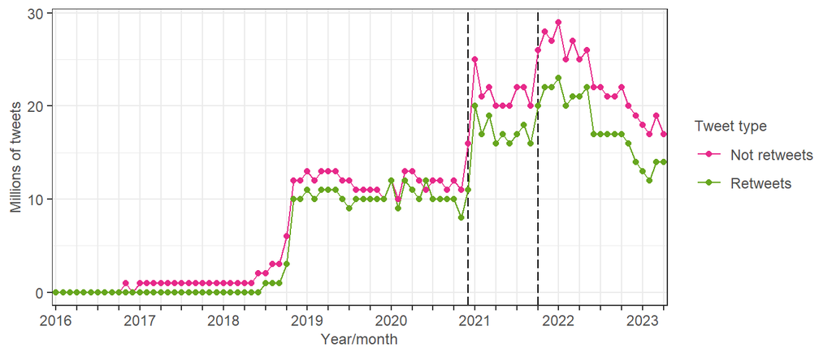

Figure 3 shows the monthly number of tweets that are retweets and not retweets for the current collection from 2016 onwards. From December 2020 to October 2021, an average of 17 million retweets per month were collected, and an average of 21 million tweets per month were collected that were not retweets.

From October 2021 onwards, an average of 18 million retweets per month have been collected, and an average of 23 million tweets per month have been collected that are not retweets.

*Figure 4.* Number of active users per month for all three collections (2016 onwards).

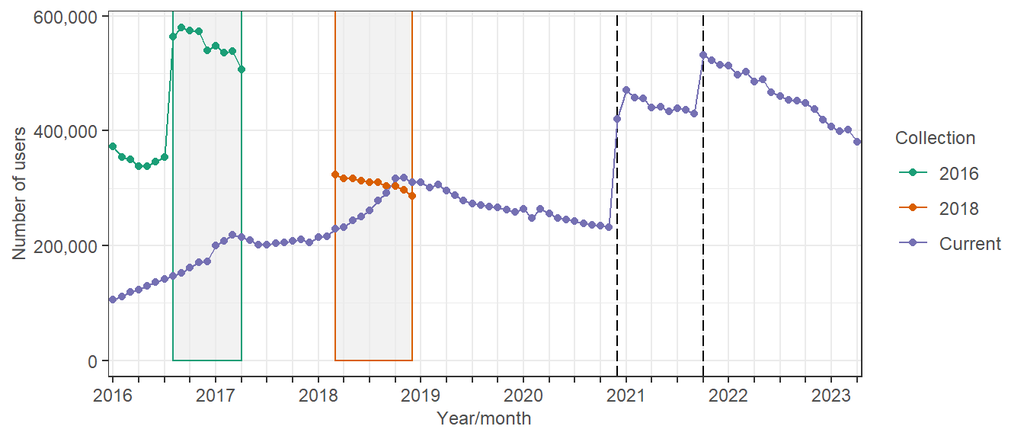

Figure 4 shows the number of users per month from 2016 onwards for all three collections that together form the Australian Twittersphere. While the 2016 collection was operating (August 2016 to April 2017), the average number of active users per month was 550,922. While the 2018 collection was operating (March 2018 to December 2018), the average number of active users per month was 307,856.

The current collection had 317,760 active users in November 2018 (the first month of collecting) and 231,097 users in November 2020 (the last month of collecting before the list of accounts in the Australian Twittersphere was updated in December 2020). From December 2020 to October 2021, the average monthly active users in the current collection was 442,467. In October 2021 the list of accounts in the Australian Twitterspher was updated again, and since that time the average monthly active users in the current collection is 462,017.

*Figure 5.* Number of users per month for all three collections (all available data).

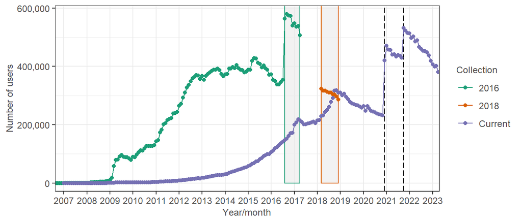

Figure 5 shows the same information as in Figure 4, but shows all available data back to as early as September 2006. Points in time at which the list of accounts was updated are represented by vertical dashed lines.

## Contact information

**Digital Observatory**  
Research Infrastructure | QUT  
[digitalobservatory.net.au/qut-digital-observatory](https://www.digitalobservatory.net.au/qut-digital-observatory/)  
digitalobservatory@qut.edu.au  
@ObservatoryTeam  
Ph: +61 7 3138 6849